# Prosper Loan Data

## by (Yosef El Desoky)

## Investigating Data set

> The data set contains of 81 variable and 113739 row containing information about loans such as Borrow's Rate ,Loan Original amount and Lender yield .....etc
> - ata set contains 113739 and 81 variable
> - There is intersting feature as the Borrower ARP ,Loan Original Amount and Leniar Yeild we will Investigate the relation between them in details

# Exploring The disturibution of diffrent Variables

> - ## Investigating the frequency of the prosperScore

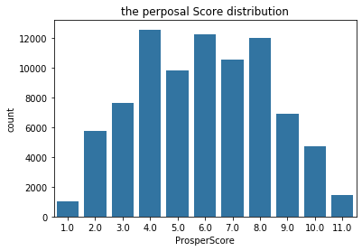

```python
sb.countplot(data=data,x='ProsperScore',color=base_color);
plt.title("the perposal Score distribution");
```

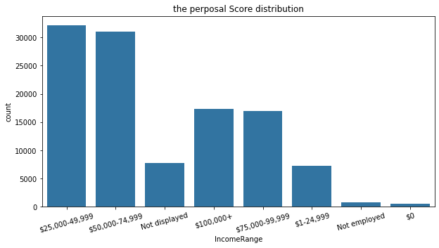

```python
plt.figure(figsize=[10,5])
sb.countplot(data=data,x='IncomeRange',color=base_color);
plt.title("the perposal Score distribution");
plt.xticks(rotation=15);
```

> - here the histogram says that the most people that tend to make loan is the people having income from 25K to 75 K
> - ## The Destrubution of the Loan Original Amount

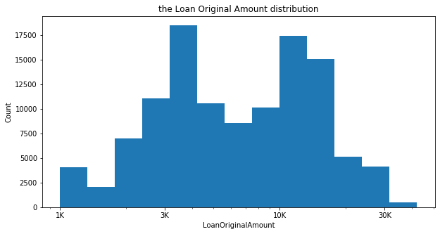

```python
bins=10**np.arange(np.log10(data['LoanOriginalAmount'].min()),np.log10(data['LoanOriginalAmount'].max())+0.125,0.125)
tick=[1000,3000,10000,30000]
tickstring=["1K","3K","10K","30K"]
plt.figure(figsize=[10,5])
plt.hist(data=data,x='LoanOriginalAmount',color=base_color,bins=bins);
plt.title("the Loan Original Amount distribution");
plt.xscale('log')
plt.xticks(tick,tickstring);
plt.xlabel('LoanOriginalAmount');
plt.ylabel('Count');
```

> - we see 2 high beek between 3k,4k and the other one between 10k and 13k saying that the most Loans amount lies on those ranges
> - ## Exploring the most frequent reason for loans

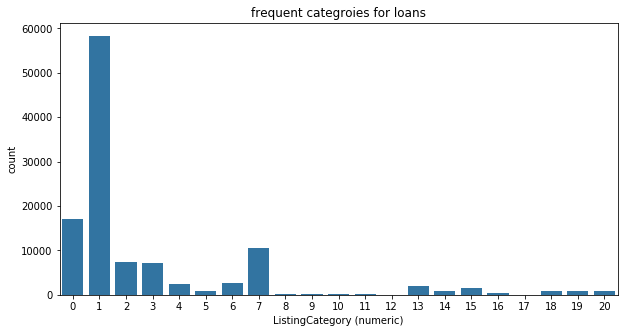

```python
plt.figure(figsize=[10,5])
sb.countplot(data=data,x='ListingCategory (numeric)',color=base_color);
plt.title("frequent categroies for loans");
```

> - This graph tell us the most frequnect reason ffor getting loans is 1)Debt Consolidation
> - ### we made a log transformation to Loan Original Amount to be able to get the distribution of the amount and it;s count and We got the following resutl that there is 2 most common ranges for the Loan amounts

# Looking at the relation between diffrent variables

> In this section, we will investigate relationships between pairs of variables to get relations.
> - ## Relation between Borrow ARP and Lender Yield

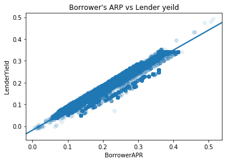

```python
sb.regplot(data=data,x='BorrowerAPR',y='LenderYield',scatter_kws={'alpha':0.1});
plt.title("Borrower's ARP vs Lender yeild");
```

> - we see here that there is a linear relation between the annual Precentage rate of the borrower's and the lender precentage as when the precentage increases for one the other also increases
> - ## The relation between Income Range and Borrowe's interset

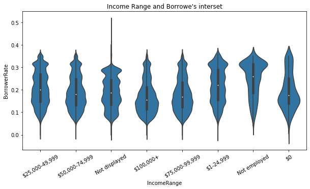

```python
plt.figure(figsize=[10,5])
sb.violinplot(data=data,x='IncomeRange',y='BorrowerRate',color=base_color)
plt.xticks(rotation=30);
plt.title("Income Range and Borrowe's interset");
```

> - Here we see that the type of people that is not employed show a high interrset in getting loans
> - ## The number of people getting loans in diffrent Employment Status

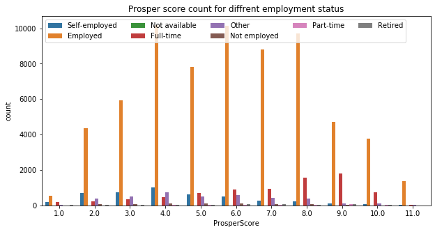

```python
plt.figure(figsize=[10,5])
sb.countplot(data=data,x='ProsperScore',hue='EmploymentStatus');
plt.legend(loc = 0, ncol = 5);
plt.title("Prosper score count for diffrent employment status");
```

> - here we concluded that the most frequent people to seek loans are employed
> - ## The number of people getting loans in diffrent Income Ranges

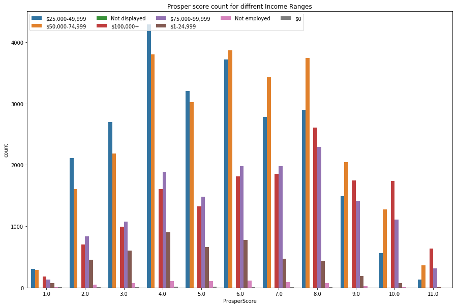

```python
plt.figure(figsize=[15,10])
sb.countplot(data=data,x='ProsperScore',hue='IncomeRange');
plt.legend(loc = 0, ncol = 5);
plt.title("Prosper score count for diffrent Income Ranges");
```

## Relation between Variable and diffrent status

> - ## Relation for Original loan and Income as a Borrower's howeowner or not

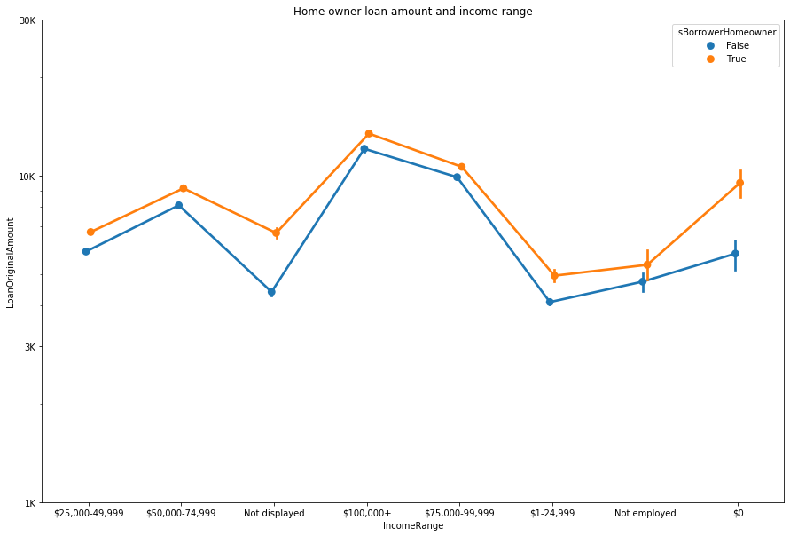

```python
plt.figure(figsize=[15,10])
sb.pointplot(data=data,x='IncomeRange',y='LoanOriginalAmount',hue='IsBorrowerHomeowner',dodge=True)
plt.yscale('log')
plt.yticks(tick,tickstring)
plt.title("Home owner loan amount and income range");
```

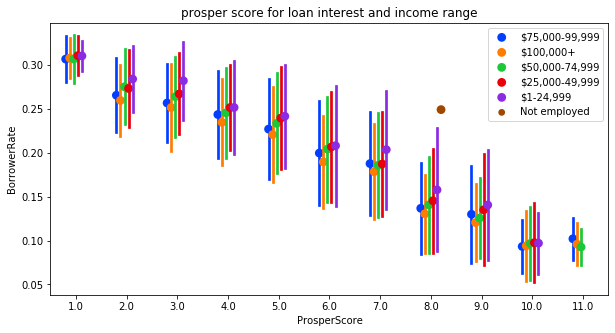

```python
plt.figure(figsize=[10,5])
data_nonan=data.dropna()
sb.pointplot(data=data_nonan,x='ProsperScore',y='BorrowerRate',
             hue='IncomeRange',palette = 'bright', linestyles = '', dodge = 0.4, ci="sd");
plt.legend();
plt.title("prosper score for loan interest and income range");
```

> - In the graph we see that people have high interest in getting loan dont't usually prosper that good also the people getting high score having low interest and we see that in most scores the distrubution of the people having income between 1 and 25K is in wide range of interest